# 2D Single Object Tracking Simulation Tests

The purpose of these slides are to demonstrate the current capability of our simulation framework and show possible outputs of the data generator.

We also take a look at how well our Kalman filter performs given different initial values.

```python
# Import our modules and set up the simulation and data generator
# we want to use, along with initial values

import numpy as np
from twod_object import TwoDObject
from tracker import Tracker
from simulation import Simulation
from kalmanfilter2 import KalmanFilter
import matplotlib.pyplot as plt

initial = [np.array([[0], [0], [1], [1]])]
dt = 1
ep_normal = 1
ep_tangent = 1
nu = 1
ts = 25
miss_p = 0

gen = TwoDObject(initial, dt, ep_tangent, ep_normal, nu, miss_p)
sim = Simulation(gen, KalmanFilter, Tracker)
```

# Data Generation Variables

In the first half of the presentation, we examine how well tracking performs under different data generation scenarios. We assume we know all aspects of process perfectly, and use these as inputs to the Kalman filter.

### Different Measurement Noise

Here, we examine how the tracking performs with different standard deviations of measurement noise (nu) over 25 time steps. As expected, more measurement noise makes the trajectory more difficult to track.

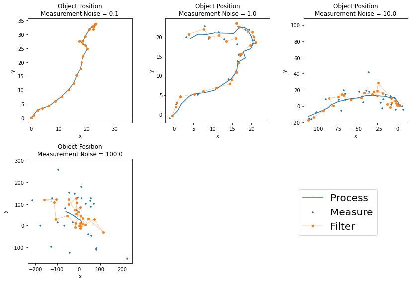

```python
sim.experiment_plot(ts, "Measurement Noise", nu = [0.1, 1, 10, 100])
```

### Different Tangent Direction Variance

Next we examine different tangent variance values. Larger values appear to yield potentially sharper turns, as in the last plot, but there does not appear to be a major difference between different tangent values over only 25 time steps, all else the same.

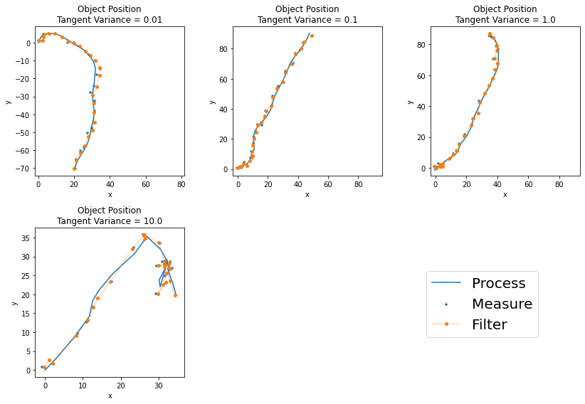

```python
sim.reset_generator(nu=1)
sim.experiment_plot(ts, "Tangent Variance", ep_tangent = [0.01, 0.1, 1, 10])
```

### Different Normal Direction Variance

In addition, we examine different variances in the normal direction. Higher values result in more frequent and sharper turns - objects that change direction more often.

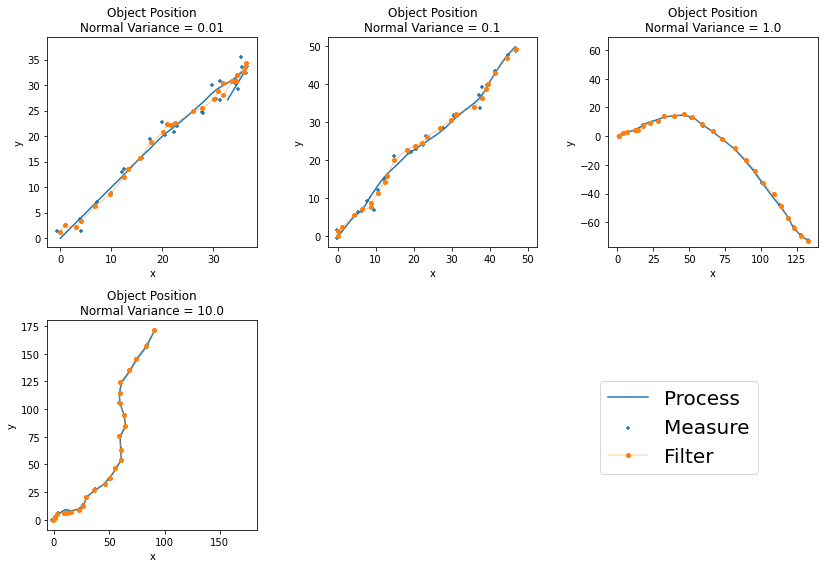

```python
sim.reset_generator(ep_tangent=1)
sim.experiment_plot(ts, "Normal Variance", ep_normal = [0.01, 0.1, 1, 10])
```

### Different Time Intervals

Finally, given the initial starting conditions defined at the beginning, we see how the trajectory of the object changes over different time intervals. Over long time intervals, the movement of the object does not appear to be drastically different compared to short intervals - besides the obvious fact that the object covers a longer distance over more time.

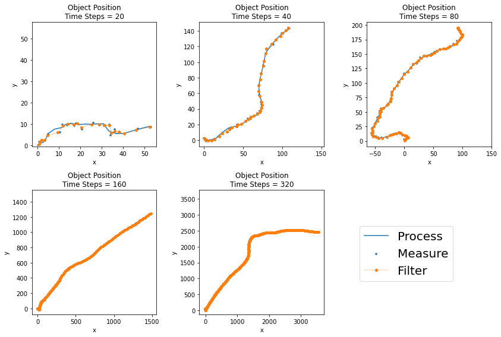

```python
sim.reset_generator(ep_normal=1)
sim.experiment_plot([20,40,80,160,320], "Time Steps", ep_normal = [1])
```

# Kalman Filter Tests

Now we examine how well the Kalman filter performs using inputs that differ from the true process.

### Lower Measurement Noise

First we test different measurement covariance matrices R, examining what happens when we assume much lower measurement noise than in reality.

At smaller R, there is a slight but negligible difference in the performance of the filter, indicating that assuming low measurement noise does not affect the filter much at all.

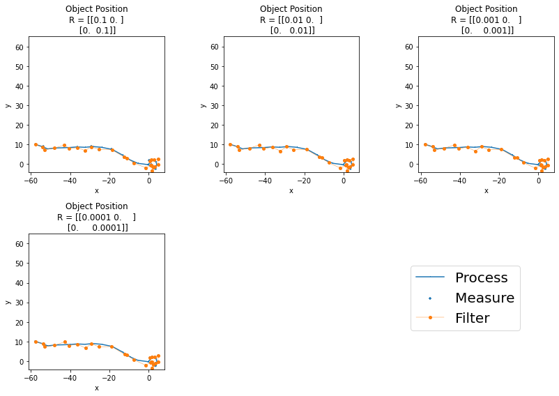

```python
R_list = [np.eye(2) *0.1 ** i for i in range(1,5)]
sim.experiment_plot(ts, "R", test = "filter", R = R_list)
```

### Lower Process Noise

Similarly, we test different values of process noise Q, examining the result when we assume much lower process noise than in reality. In this case, the filter tracks the trajectory less accurately when lower noise is assumed, but the predicted trajectory is still relatively close to the true trajectory.

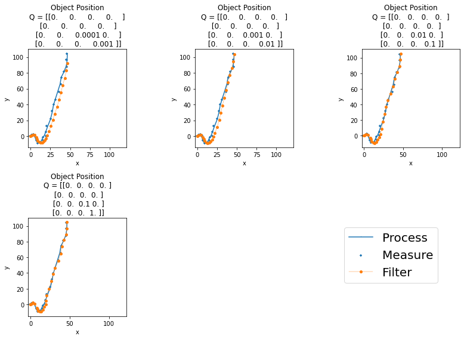

```python
Q0 = np.diag(np.append(np.zeros(2), np.append(np.array([0.0001]), np.array(0.001))))
Q_list = [Q0 * 10**i for i in range(0,4)]

sim.experiment_plot(ts, "Q", test = "filter", Q = Q_list)
```

### Inaccurate Starting Values

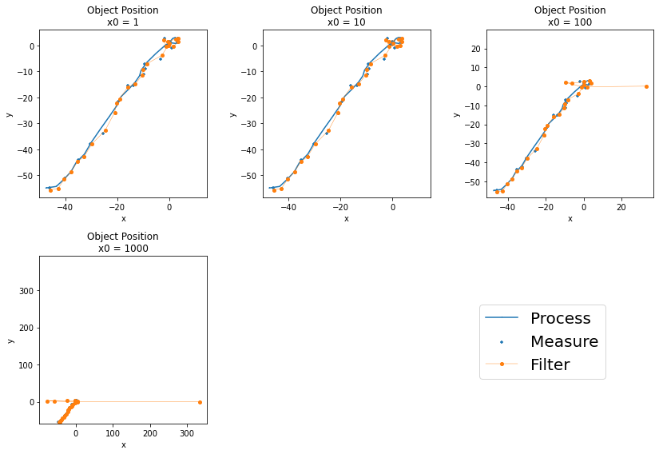

```python
initial = np.array([[1], [0],[0],[0]])
init_list = [[initial * 10**i] for i in range(0,4)]
sim.experiment_plot(ts, "x0", test = "filter", x0 = init_list)
```